# Dhairya Kothari

### kNN with MNIST-Machine Learning

```python
import os
import gzip
import math
import operator
import sklearn.model_selection
import random

import matplotlib.pyplot as matplot
import matplotlib
%matplotlib inline
import pandas as pd
import numpy as np
import pickle as cPickle

from time import time
from itertools import chain
from collections import Counter
from PIL import Image
from scipy.stats import mode
from sklearn.metrics import confusion_matrix
from sklearn.metrics import accuracy_score
```

### 1NN

#### Importing the data from tensorflow package and checking the shape of the training and testing data set

```python
from tensorflow.examples.tutorials.mnist import input_data
mnist = input_data.read_data_sets('MNIST_data/')
```

```
Extracting MNIST_data/train-images-idx3-ubyte.gz
Extracting MNIST_data/train-labels-idx1-ubyte.gz
Extracting MNIST_data/t10k-images-idx3-ubyte.gz
Extracting MNIST_data/t10k-labels-idx1-ubyte.gz
```

```python
train = mnist.train.images
validation = mnist.validation.images
test = mnist.test.images

trlab = mnist.train.labels
vallab = mnist.validation.labels
tslab = mnist.test.labels

train = np.concatenate((train, validation), axis=0)
trlab = np.concatenate((trlab, vallab), axis=0)
```

```python
train.shape
```

```
(60000, 784)
```

```python
trlab.shape
```

```
(60000,)
```

```python
test.shape
```

```
(10000, 784)
```

#### Example image (28 x 28 pixels)

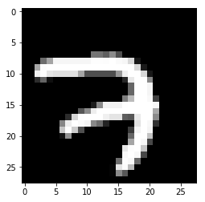

```python
x = np.reshape(train[0], [28,28])
matplot.imshow(x, cmap='Greys_r')
```

#### Checking the distribution of color (greyscale) in the image

0 = Black ; 1 = White

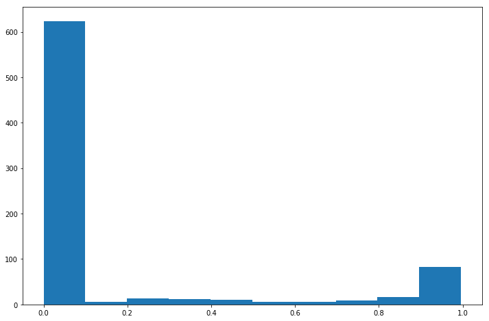

```python
matplot.subplots(figsize=(12, 8))
matplot.hist(train[0])
matplot.show()
```

#### Some example images with their corresponding labels

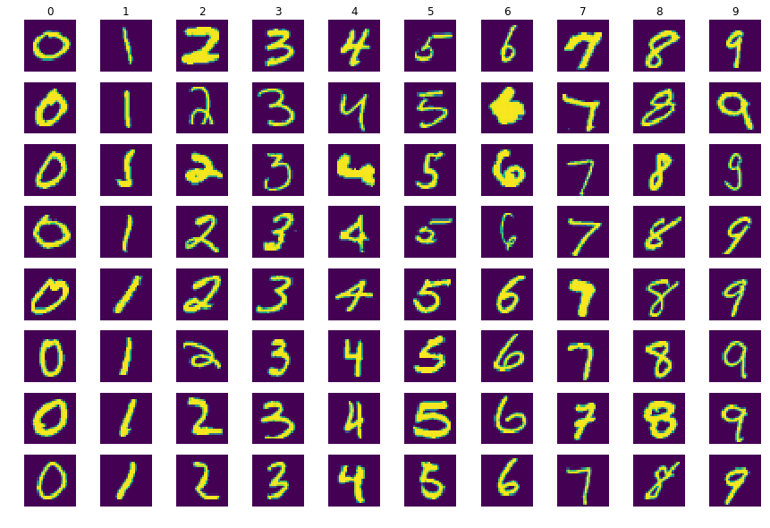

```python
classes = ["0", "1", "2", "3", "4", "5", "6", "7", "8", "9"]
num_classes = len(classes)
samples = 8

matplot.subplots(figsize=(15, 10))
for y, cls in enumerate(classes):
    idxs = np.nonzero([i == y for i in trlab])
    idxs = np.random.choice(idxs[0], samples, replace=False)
    for i , idx in enumerate(idxs):
        plt_idx = i * num_classes + y + 1
        matplot.subplot(samples, num_classes, plt_idx)
        matplot.imshow(train[idx].reshape((28, 28)))
        matplot.axis("off")
        if i == 0:
            matplot.title(cls)


matplot.show()
```

We can see that the machine can confuse 1 with 7 similarly, 9 is very close to 4, 0 to 8 and 2 is very close to 7 in some instances. We might encounter error in prediction in these cases

#### KNN function

```python
def knn(train, train_label, test, test_label, k):
    pred = []
    for w in range(len(test)):
        test_1 = test[w]
        diff = (train - test_1)
        dist = np.einsum('ij, ij->i', diff, diff)  #distance measure
        nearest_lbs = train_label[np.argsort(dist)[:k]]
        major = mode(nearest_lbs)[0][0]
        pred.append(major)

    cm = pd.DataFrame(confusion_matrix(test_label, pred))
    err = 1-accuracy_score(test_label, pred)
    return [err,cm,pred]
```

```python
st = time()
Q1 = knn(train,trlab,test,tslab,1)
t = time() - st
```

#### Results of 1NN

```python
print(Q1[0]) #Error Rate
```

```
0.0309
```

```python
print(t) #time taken (in seconds) for classifying 10000 test images
print(t/10000) #Query time (in seconds) for 1 image classification
```

```
870.1476261615753
0.08701476261615754
```

```python
print(1-Q1[0]) #Accuracy
```

```
0.9691
```

```python
print(Q1[1]) #Confusion Matrix: Original Label VS Predicted Value
```

```
     0     1    2    3    4    5    6    7    8    9
0  973     1    1    0    0    1    3    1    0    0
1    0  1129    3    0    1    1    1    0    0    0
2    7     6  992    5    1    0    2   16    3    0
3    0     1    2  970    1   19    0    7    7    3
4    0     7    0    0  944    0    3    5    1   22
5    1     1    0   12    2  860    5    1    6    4
6    4     2    0    0    3    5  944    0    0    0
7    0    14    6    2    4    0    0  992    0   10
8    6     1    3   14    5   13    3    4  920    5
9    2     5    1    6   10    5    1   11    1  967
```

#### Error rate for individual digits

- After implementing the 1NN we get a very good error rate of 3.09 %  
- Error is particularly high in 2,3,4,5,7,8 and 9 highest among them is 8  
- there is misprediction between 7 with 1; 8 and 5 with 3; 9 with 4; and 7 with 2

#### KNN with Leave one out Cross validation

```python
def knncv(data, label, klist):
    df = pd.DataFrame(index=range(len(label)), columns=range(len(klist)))
    for p in range(len(label)):
        te = data[p]
        te_lb = label[p]
        tr = np.delete(data, p, 0)
        train_label = np.delete(label, p)

        diff = (tr - te)
        dis = np.einsum('ij, ij->i', diff, diff)
        for i, k in enumerate(klist):
            near = train_label[np.argsort(dis)[:k]]
            pick = mode(near)[0][0]
            if pick == te_lb:
                df.iloc[p][i] = 0
            else:
                df.iloc[p][i] = 1

    return df
```

#### LOOCV kNN for k values 1 to 20

```python
Q2 = knncv(train, trlab, range(1,21))
# print(np.mean(Q2, axis = 0)) # Error rate for K values (1 to 20)
```

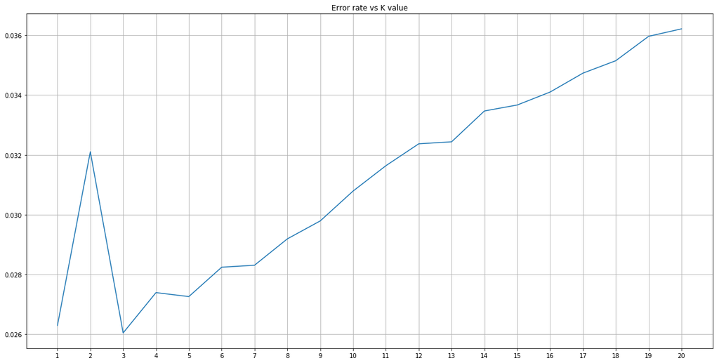

```python
matplot.subplots(figsize=(20, 10))
matplot.plot(np.mean(Q2, axis = 0))
matplot.xticks(range(0,20), range(1,21))
matplot.grid(True)
matplot.title('Error rate vs K value')
matplot.show()
```

#### K = 3 seems to give the best result

```python
st = time()
Q2a = knn(train,trlab,test,tslab,3)
t = time()-st
print(t/10000) #Query time (in seconds) for 1 image classification for 3NN
```

```
0.08965984258651734
```

#### Results for 3NN

```python
print(Q2a[0]*100) #Error Rate
```

```
2.95
```

```python
print(Q2a[1]) #Confusion Matrix
```

```
     0     1    2    3    4    5    6    7    8    9
0  974     1    1    0    0    1    2    1    0    0
1    0  1133    2    0    0    0    0    0    0    0
2   10     9  996    2    0    0    0   13    2    0
3    0     2    4  976    1   13    1    7    3    3
4    1     6    0    0  950    0    4    2    0   19
5    6     1    0   11    2  859    5    1    3    4
6    5     3    0    0    3    3  944    0    0    0
7    0    21    5    0    1    0    0  991    0   10
8    8     2    4   16    8   11    3    4  914    4
9    4     5    2    8    9    2    1    8    2  968
```

#### Error rate for individual digits

0 - 0.006122  
1 - 0.001762  
2 - 0.034884  
3 - 0.033663  
4 - 0.032587  
5 - 0.036996  
6 - 0.014614  
7 - 0.035992  
8 - 0.061602  
9 - 0.040634

Importing data

```python
import os
import gzip
import math
import operator
import sklearn.model_selection
import random

import matplotlib.pyplot as matplot
import matplotlib
%matplotlib inline
import pandas as pd
import numpy as np
import pickle as cPickle

from time import time
from itertools import chain
from collections import Counter
from PIL import Image
from scipy.stats import mode
from sklearn.metrics import confusion_matrix
from sklearn.metrics import accuracy_score
```

```python
from tensorflow.examples.tutorials.mnist import input_data
mnist = input_data.read_data_sets('MNIST_data/')
```

```
Extracting MNIST_data/train-images-idx3-ubyte.gz
Extracting MNIST_data/train-labels-idx1-ubyte.gz
Extracting MNIST_data/t10k-images-idx3-ubyte.gz
Extracting MNIST_data/t10k-labels-idx1-ubyte.gz
```

```python
train = mnist.train.images
validation = mnist.validation.images
test = mnist.test.images

trlab = mnist.train.labels
vallab = mnist.validation.labels
tslab = mnist.test.labels

train = np.concatenate((train, validation), axis=0)
trlab = np.concatenate((trlab, vallab), axis=0)
```

KNN function

```python
def knn(train, train_label, test, test_label, k):
    pred = []
    for w in range(len(test)):
        test_1 = test[w]
        diff = (train - test_1)
        dist = np.einsum('ij, ij->i', diff, diff)  #distance measure
        nearest_lbs = train_label[np.argsort(dist)[:k]]
        major = mode(nearest_lbs)[0][0]
        pred.append(major)

    cm = pd.DataFrame(confusion_matrix(test_label, pred))
    err = 1-accuracy_score(test_label, pred)
    return [err,cm,pred]
```

Defining the error rate for the kNN to display in a tabulated format

```python
def error_rate(confusion_matrix):
    a = confusion_matrix
    b = a.sum(axis=1)
    df = []
    for i in range(0,10):
        temp = 1-a[i][i]/b[i]
        df.append(temp)

    df = pd.DataFrame(df)
    df.columns = ['Error rate']
    return df
```

KNN with Leave-one-out Cross validation

```python
def knncv(data, label, klist):
    df = pd.DataFrame(index=range(len(label)), columns=range(len(klist)))
    for p in range(len(label)):
        te = data[p]
        te_lb = label[p]
        tr = np.delete(data, p, 0)
        train_label = np.delete(label, p)

        diff = (tr - te)
        dis = np.einsum('ij, ij->i', diff, diff)
        for i, k in enumerate(klist):
            near = train_label[np.argsort(dis)[:k]]
            pick = mode(near)[0][0]
            if pick == te_lb:
                df.iloc[p][i] = 0
            else:
                df.iloc[p][i] = 1

    return df
```

#### Generating random sample of the data

```python
#generating a random sequence for sampling
seq = np.random.randint(0,60000,6000)
train_samp = train[seq]
trlab_samp = trlab[seq]

train_samp.shape
trlab_samp.shape
```

```
(6000,)
```

#### Comparing sampled data distribution with the original

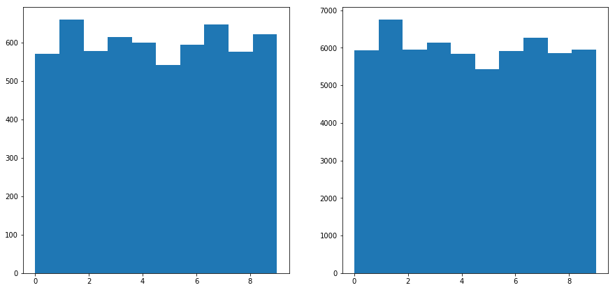

```python
fig, ax = matplot.subplots(1,2, figsize=(15,7))
ax[0].hist(trlab_samp)
ax[1].hist(trlab)
fig.show
matplot.show()
```

### Downsampling

#### Defining the downsampling function

```python
def downsamples(n, data):
    rn = range(0,784,n)
    data = data[:, rn]
    return data
```

#### N=4 down sampling

```python
q3tr = downsamples(4, train_samp)
q3tr_full = downsamples(4, train)
q3ts = downsamples(4, test)
```

```python
q3n4 = knncv(q3tr, trlab_samp, range(1,21))
```

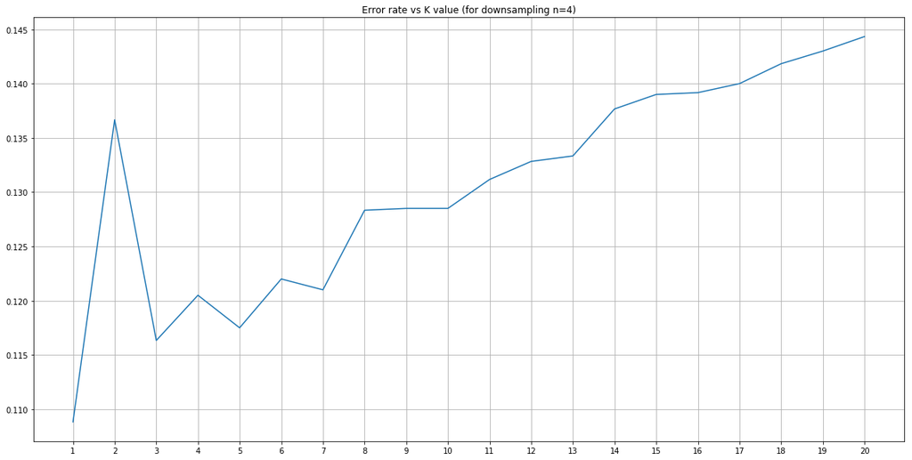

```python
matplot.subplots(figsize=(20, 10))
matplot.plot(np.mean(q3n4, axis = 0))
matplot.xticks(range(0,20), range(1,21))
matplot.grid(True)
matplot.title('Error rate vs K value (for downsampling n=4)')
matplot.show()
```

#### Best k: k=1

```python
st = time()
q3a = knn(q3tr_full, trlab, q3ts, tslab, 1)
end = time() - st
t3a = end/len(tslab) # Query time
```

```python
print(q3a[0]) #Error rate
```

```
0.074
```

```python
q3a[1] #Confusion matrix
```

|  | 0 | 1 | 2 | 3 | 4 | 5 | 6 | 7 | 8 | 9 |
| --- | --- | --- | --- | --- | --- | --- | --- | --- | --- | --- |
| 0 | 961 | 5 | 0 | 0 | 0 | 4 | 7 | 1 | 1 | 1 |
| 1 | 1 | 1117 | 2 | 0 | 7 | 0 | 5 | 3 | 0 | 0 |
| 2 | 15 | 12 | 953 | 13 | 5 | 1 | 3 | 15 | 14 | 1 |
| 3 | 3 | 9 | 7 | 915 | 1 | 25 | 3 | 11 | 25 | 11 |
| 4 | 0 | 23 | 4 | 1 | 894 | 1 | 6 | 4 | 2 | 47 |
| 5 | 7 | 8 | 1 | 30 | 5 | 788 | 16 | 4 | 19 | 14 |
| 6 | 5 | 9 | 0 | 0 | 4 | 13 | 926 | 0 | 1 | 0 |
| 7 | 1 | 28 | 8 | 0 | 14 | 0 | 1 | 955 | 1 | 20 |
| 8 | 9 | 14 | 7 | 43 | 12 | 22 | 2 | 12 | 835 | 18 |
| 9 | 4 | 13 | 2 | 13 | 31 | 5 | 1 | 21 | 3 | 916 |

```python
error_rate(q3a[1]) #Individual digit errors
```

|  | Error rate |
| --- | --- |
| 0 | 0.019388 |
| 1 | 0.015859 |
| 2 | 0.076550 |
| 3 | 0.094059 |
| 4 | 0.089613 |
| 5 | 0.116592 |
| 6 | 0.033403 |
| 7 | 0.071012 |
| 8 | 0.142710 |
| 9 | 0.092170 |

#### N=7 down sampling

```python
q3btr = downsamples(7, train_samp)
q3btr_full = downsamples(7, train)
q3bts = downsamples(7, test)
```

```python
q3n7 = knncv(q3btr, trlab_samp, range(1,21))
```

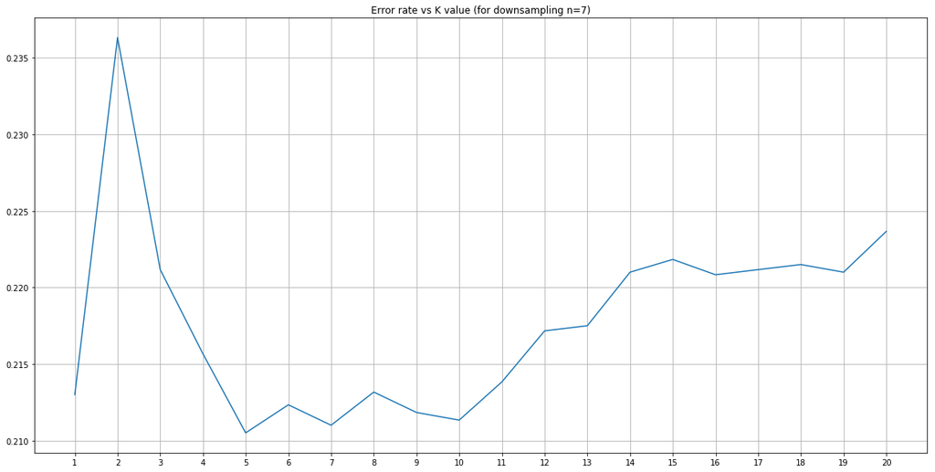

```python
matplot.subplots(figsize=(20, 10))
matplot.plot(np.mean(q3n7, axis = 0))
matplot.xticks(range(0,20), range(1,21))
matplot.grid(True)
matplot.title('Error rate vs K value (for downsampling n=7)')
matplot.show()
```

#### Best k: k = 5

```python
st = time()
q3b = knn(q3btr_full, trlab, q3bts, tslab, 5)
end = time() - st
t3b=end/len(tslab) # Query time
```

```python
print(q3b[0]) #Error rate
```

```
0.1535
```

```python
q3b[1] #Confusion Matrix
```

|  | 0 | 1 | 2 | 3 | 4 | 5 | 6 | 7 | 8 | 9 |
| --- | --- | --- | --- | --- | --- | --- | --- | --- | --- | --- |
| 0 | 956 | 1 | 1 | 5 | 1 | 3 | 9 | 3 | 0 | 1 |
| 1 | 1 | 1118 | 3 | 2 | 2 | 2 | 2 | 2 | 0 | 3 |
| 2 | 28 | 12 | 823 | 32 | 16 | 11 | 45 | 24 | 38 | 3 |
| 3 | 16 | 3 | 16 | 804 | 1 | 39 | 23 | 9 | 84 | 15 |
| 4 | 1 | 42 | 7 | 1 | 824 | 8 | 17 | 18 | 9 | 55 |
| 5 | 21 | 5 | 9 | 75 | 13 | 655 | 29 | 23 | 42 | 20 |
| 6 | 28 | 16 | 18 | 8 | 19 | 14 | 843 | 6 | 3 | 3 |
| 7 | 4 | 19 | 14 | 1 | 15 | 4 | 6 | 912 | 10 | 43 |
| 8 | 7 | 17 | 14 | 126 | 17 | 52 | 13 | 19 | 679 | 30 |
| 9 | 9 | 15 | 4 | 7 | 31 | 18 | 2 | 53 | 19 | 851 |

```python
error_rate(q3b[1]) #Individual digit errors
```

|  | Error rate |
| --- | --- |
| 0 | 0.024490 |
| 1 | 0.014978 |
| 2 | 0.202519 |
| 3 | 0.203960 |
| 4 | 0.160896 |
| 5 | 0.265695 |
| 6 | 0.120042 |
| 7 | 0.112840 |
| 8 | 0.302875 |
| 9 | 0.156591 |

#### N = 14 downsampling

```python
q3ctr = downsamples(14, train_samp)
q3ctr_full = downsamples(14, train)
q3cts = downsamples(14, test)
```

```python
q3n14 = knncv(q3ctr, trlab_samp, range(1,21))
```

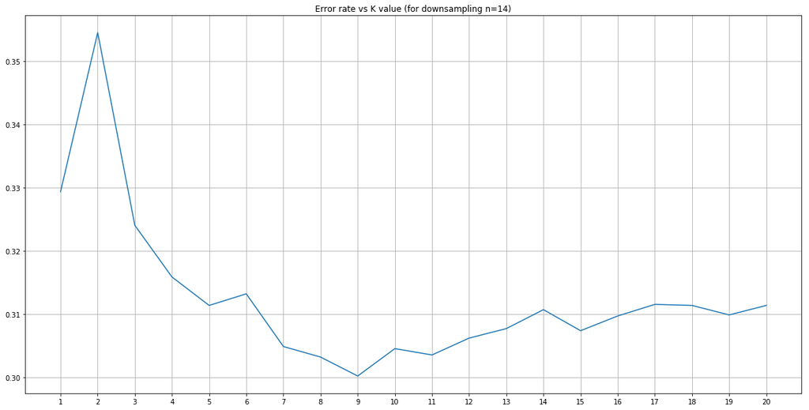

```python
matplot.subplots(figsize=(20, 10))
matplot.plot(np.mean(q3n14, axis = 0))
matplot.xticks(range(0,20), range(1,21))
matplot.grid(True)
matplot.title('Error rate vs K value (for downsampling n=14)')
matplot.show()
```

#### best k: k = 9

```python
st = time()
q3c = knn(q3ctr_full, trlab, q3cts, tslab, 9)
end = time() - st
t3c = end/len(tslab) # Query time
```

```python
print(q3c[0]) #Error rate
```

```
0.2616
```

```python
q3c[1] #Confusion Matrix
```

|  | 0 | 1 | 2 | 3 | 4 | 5 | 6 | 7 | 8 | 9 |
| --- | --- | --- | --- | --- | --- | --- | --- | --- | --- | --- |
| 0 | 913 | 1 | 9 | 10 | 2 | 5 | 16 | 19 | 4 | 1 |
| 1 | 2 | 1086 | 8 | 2 | 17 | 2 | 5 | 2 | 9 | 2 |
| 2 | 18 | 26 | 675 | 56 | 20 | 33 | 85 | 34 | 56 | 29 |
| 3 | 36 | 1 | 31 | 706 | 2 | 84 | 25 | 4 | 111 | 10 |
| 4 | 3 | 67 | 35 | 1 | 733 | 11 | 27 | 34 | 13 | 58 |
| 5 | 46 | 9 | 16 | 116 | 17 | 486 | 63 | 64 | 38 | 37 |
| 6 | 50 | 13 | 95 | 20 | 44 | 60 | 650 | 15 | 7 | 4 |
| 7 | 20 | 16 | 41 | 3 | 15 | 18 | 8 | 840 | 18 | 49 |
| 8 | 4 | 22 | 48 | 201 | 14 | 46 | 17 | 22 | 546 | 54 |
| 9 | 14 | 11 | 21 | 17 | 28 | 45 | 6 | 72 | 46 | 749 |

```python
error_rate(q3c[1]) #Individual digit errors
```

|  | Error rate |
| --- | --- |
| 0 | 0.068367 |
| 1 | 0.043172 |
| 2 | 0.345930 |
| 3 | 0.300990 |
| 4 | 0.253564 |
| 5 | 0.455157 |
| 6 | 0.321503 |
| 7 | 0.182879 |
| 8 | 0.439425 |
| 9 | 0.257681 |

#### N = 2 downsampling

```python
q3dtr = downsamples(2, train_samp)
q3dtr_full = downsamples(2, train)
q3dts = downsamples(2, test)
```

```python
q3n2 = knncv(q3dtr, trlab_samp, range(1,21))
```

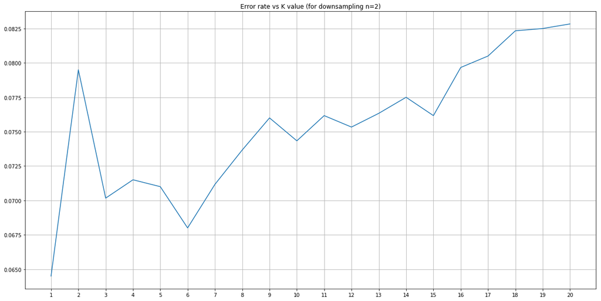

```python
matplot.subplots(figsize=(20, 10))
matplot.plot(np.mean(q3n2, axis = 0))
matplot.xticks(range(0,20), range(1,21))
matplot.grid(True)
matplot.title('Error rate vs K value (for downsampling n=2)')
matplot.show()
```

#### best k: k = 1

```python
st = time()
q3d = knn(q3dtr_full, trlab, q3dts, tslab, 1)
end = time() - st
t3d = end/len(tslab) # Query time
```

```python
print(q3d[0]) #Error rate
```

```
0.0359
```

```python
q3d[1] #Confusion Matrix
```

|  | 0 | 1 | 2 | 3 | 4 | 5 | 6 | 7 | 8 | 9 |
| --- | --- | --- | --- | --- | --- | --- | --- | --- | --- | --- |
| 0 | 973 | 1 | 1 | 0 | 0 | 1 | 3 | 1 | 0 | 0 |
| 1 | 0 | 1132 | 2 | 1 | 0 | 0 | 0 | 0 | 0 | 0 |
| 2 | 7 | 5 | 991 | 6 | 1 | 0 | 3 | 16 | 3 | 0 |
| 3 | 0 | 2 | 2 | 959 | 1 | 26 | 0 | 9 | 6 | 5 |
| 4 | 1 | 5 | 0 | 0 | 936 | 0 | 3 | 3 | 2 | 32 |
| 5 | 1 | 1 | 0 | 15 | 2 | 853 | 7 | 2 | 5 | 6 |
| 6 | 6 | 4 | 0 | 0 | 4 | 5 | 938 | 0 | 1 | 0 |
| 7 | 0 | 18 | 7 | 2 | 4 | 0 | 0 | 988 | 0 | 9 |
| 8 | 4 | 2 | 4 | 19 | 6 | 13 | 3 | 4 | 909 | 10 |
| 9 | 1 | 4 | 1 | 7 | 13 | 4 | 1 | 12 | 4 | 962 |

```python
error_rate(q3d[1])
```

|  | Error rate |
| --- | --- |
| 0 | 0.007143 |
| 1 | 0.002643 |
| 2 | 0.039729 |
| 3 | 0.050495 |
| 4 | 0.046843 |
| 5 | 0.043722 |
| 6 | 0.020877 |
| 7 | 0.038911 |
| 8 | 0.066735 |
| 9 | 0.046581 |

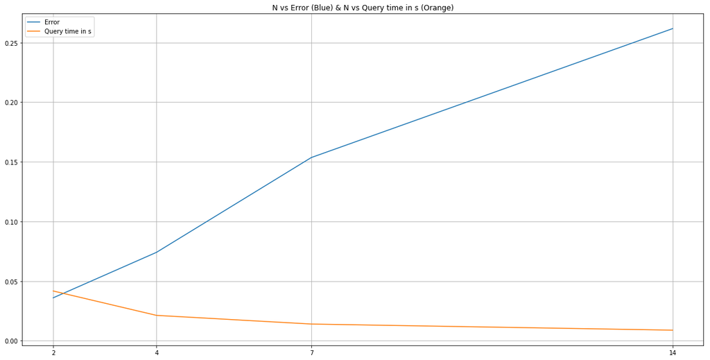

```python
n = [2,4,7,14]
err = [q3d[0],q3a[0],q3b[0],q3c[0]]
t = [t3d,t3a,t3b,t3c]

matplot.subplots(figsize=(20, 10))
matplot.plot(n, err, label="Error") # Blue
matplot.plot(n, t, label="Query time in s") # Orange
matplot.xticks(n,n)
matplot.grid(True)
matplot.legend()
matplot.title('N vs Error (Blue) & N vs Query time in s (Orange)')
matplot.show()
```

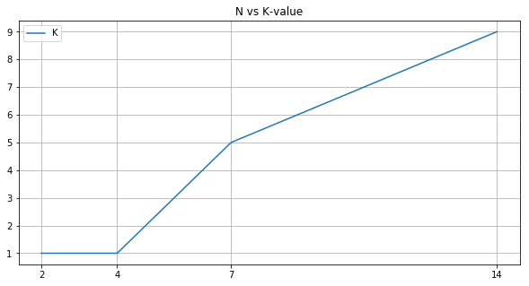

```python
n = [2,4,7,14]
k_val = [1,1,5,9]

matplot.subplots(figsize=(10, 5))
matplot.plot(n, k_val, label="K")
matplot.xticks(n,n)
matplot.legend()
matplot.grid(True)
matplot.title('N vs K-value')
matplot.show()
```

- The query time decreases as the downsampling factor N increases
- As N increases, K increases as well
- But also, as N increases, the Error rate increases
- Between N = 2 to N = 4 we have a sweet spot between K, Query time and Error Rate

### Smart Down Sampling

```python
def downsample2(n, data):
    res = []
    for i in range(len(data)):
        temp = []
        sample = np.reshape(data[i], (28,28))
        row = np.asarray(np.split(sample, int(28 / n), axis=0))
        for j in range(int(28 / n)):
            col = np.asarray(np.split(row[j], int(28 / n), axis=1))
            add = np.asarray([np.sum(x) for x in col])
            temp.append(np.ndarray.tolist(add))

        res.append(list(chain.from_iterable(temp)))

    ndim = int(28 / n) * int(28 / n)
    data = np.asarray([np.reshape(y, (ndim)) for y in res])
    return data
```

#### N = 4 smart sampling

```python
q4atr = downsample2(4, train_samp)
q4atr_full = downsample2(4, train)
q4ats = downsample2(4, test)
```

Smartsampled image

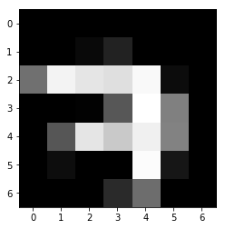

```python
x1 = np.reshape(q4atr_full[0], [7,7])
matplot.imshow(x1, cmap='Greys_r')
matplot.show()
```

```python
q4n4 = knncv(q4atr, trlab_samp, range(1,21))
```

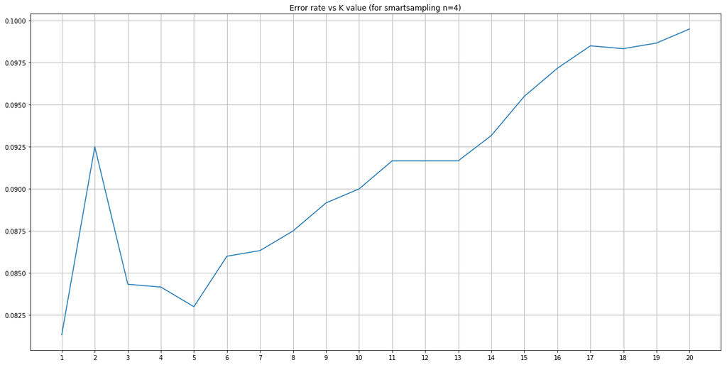

```python
matplot.subplots(figsize=(20, 10))
matplot.plot(np.mean(q4n4, axis = 0))
matplot.xticks(range(0,20), range(1,21))
matplot.grid(True)
matplot.title('Error rate vs K value (for smartsampling n=4)')
matplot.show()
```

#### best k: k = 1

```python
st = time()
q4a = knn(q4atr_full, trlab, q4ats, tslab, 1)
end = time() - st
t4a = end/len(tslab) # Query time
```

```python
print(q4a[0]) # Error rate
```

```
0.0541
```

```python
q4a[1] # Confusion matrix
```

|  | 0 | 1 | 2 | 3 | 4 | 5 | 6 | 7 | 8 | 9 |
| --- | --- | --- | --- | --- | --- | --- | --- | --- | --- | --- |
| 0 | 970 | 1 | 0 | 0 | 1 | 2 | 3 | 1 | 1 | 1 |
| 1 | 0 | 1127 | 0 | 0 | 0 | 0 | 3 | 1 | 3 | 1 |
| 2 | 1 | 2 | 982 | 5 | 2 | 0 | 4 | 21 | 13 | 2 |
| 3 | 1 | 1 | 8 | 914 | 0 | 31 | 0 | 11 | 31 | 13 |
| 4 | 1 | 0 | 0 | 0 | 906 | 0 | 13 | 5 | 4 | 53 |
| 5 | 4 | 1 | 2 | 33 | 1 | 819 | 12 | 4 | 9 | 7 |
| 6 | 7 | 3 | 2 | 0 | 5 | 8 | 931 | 0 | 1 | 1 |
| 7 | 0 | 8 | 12 | 4 | 5 | 0 | 0 | 965 | 3 | 31 |
| 8 | 6 | 3 | 4 | 13 | 7 | 14 | 3 | 8 | 910 | 6 |
| 9 | 3 | 7 | 0 | 11 | 23 | 3 | 1 | 19 | 7 | 935 |

```python
error_rate(q4a[1])
```

|  | Error rate |
| --- | --- |
| 0 | 0.010204 |
| 1 | 0.007048 |
| 2 | 0.048450 |
| 3 | 0.095050 |
| 4 | 0.077393 |
| 5 | 0.081839 |
| 6 | 0.028184 |
| 7 | 0.061284 |
| 8 | 0.065708 |
| 9 | 0.073340 |

#### N = 7 smart sampling

```python
q4btr = downsample2(7, train_samp)
q4btr_full = downsample2(7, train)
q4bts = downsample2(7, test)
```

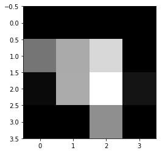

```python
x1 = np.reshape(q4btr_full[0], [4,4])
matplot.imshow(x1, cmap='Greys_r')
matplot.show()
```

```python
q4n7 = knncv(q4btr, trlab_samp, range(1,21))
```

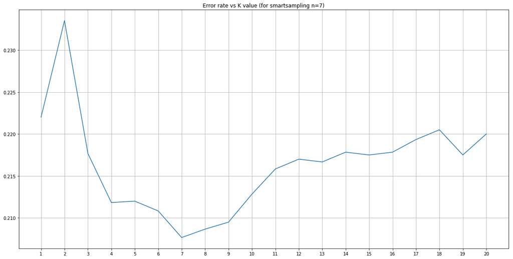

```python
matplot.subplots(figsize=(20, 10))
matplot.plot(np.mean(q4n7, axis = 0))
matplot.xticks(range(0,20), range(1,21))
matplot.grid(True)
matplot.title('Error rate vs K value (for smartsampling n=7)')
matplot.show()
```

#### best k: k = 7

```python
st = time()
q4b = knn(q4btr_full, trlab, q4bts, tslab, 7)
end = time() - st
t4b = end/len(tslab) # Query time
```

```python
print(q4b[0]) # Error rate
```

```
0.1744
```

```python
q4b[1] # Confusion matrix
```

|  | 0 | 1 | 2 | 3 | 4 | 5 | 6 | 7 | 8 | 9 |
| --- | --- | --- | --- | --- | --- | --- | --- | --- | --- | --- |
| 0 | 798 | 3 | 6 | 5 | 8 | 16 | 15 | 1 | 124 | 4 |
| 1 | 5 | 1098 | 1 | 4 | 3 | 1 | 5 | 3 | 10 | 5 |
| 2 | 23 | 7 | 876 | 46 | 11 | 8 | 25 | 7 | 26 | 3 |
| 3 | 11 | 15 | 32 | 828 | 2 | 26 | 2 | 34 | 40 | 20 |
| 4 | 6 | 7 | 11 | 0 | 755 | 17 | 16 | 13 | 2 | 155 |
| 5 | 19 | 4 | 7 | 39 | 15 | 707 | 17 | 18 | 52 | 14 |
| 6 | 12 | 10 | 5 | 2 | 14 | 6 | 899 | 0 | 10 | 0 |
| 7 | 1 | 29 | 10 | 12 | 35 | 7 | 1 | 846 | 2 | 85 |
| 8 | 140 | 24 | 5 | 23 | 8 | 45 | 8 | 12 | 686 | 23 |
| 9 | 12 | 16 | 5 | 14 | 108 | 8 | 3 | 69 | 11 | 763 |

```python
error_rate(q4b[1])
```

|  | Error rate |
| --- | --- |
| 0 | 0.185714 |
| 1 | 0.032599 |
| 2 | 0.151163 |
| 3 | 0.180198 |
| 4 | 0.231161 |
| 5 | 0.207399 |
| 6 | 0.061587 |
| 7 | 0.177043 |
| 8 | 0.295688 |
| 9 | 0.243806 |

#### N = 14 super sampling

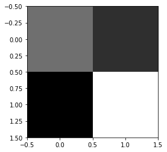

```python
q4ctr = downsample2(14, train_samp)
q4ctr_full = downsample2(14, train)
q4cts = downsample2(14, test)

x1 = np.reshape(q4ctr_full[0], [2,2])
matplot.imshow(x1, cmap='Greys_r')
matplot.show()
```

```python
q4n14 = knncv(q4ctr, trlab_samp, range(1,21))
```

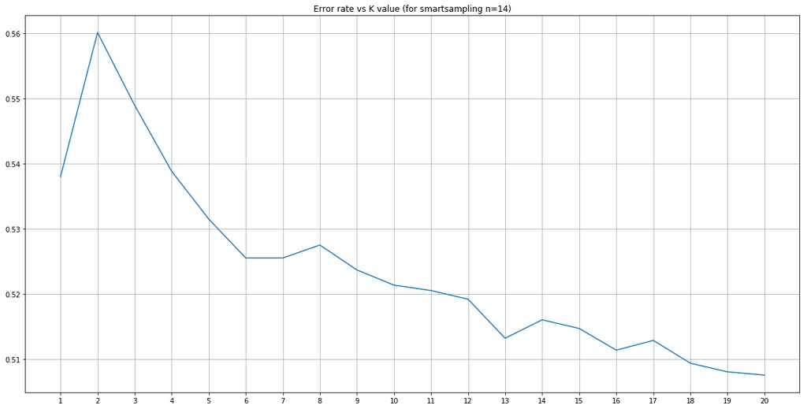

```python
matplot.subplots(figsize=(20, 10))
matplot.plot(np.mean(q4n14, axis = 0))
matplot.xticks(range(0,20), range(1,21))
matplot.grid(True)
matplot.title('Error rate vs K value (for smartsampling n=14)')
matplot.show()
```

#### best k: k = 20

```python
st = time()
q4c = knn(q4ctr_full, trlab, q4cts, tslab, 20)
end = time() - st
t4c = end/len(tslab) # Query time
```

```python
print(q4c[0]) # Error rate
```

```
0.493
```

```python
q4c[1] # Confusion matrix
```

|  | 0 | 1 | 2 | 3 | 4 | 5 | 6 | 7 | 8 | 9 |
| --- | --- | --- | --- | --- | --- | --- | --- | --- | --- | --- |
| 0 | 698 | 3 | 26 | 33 | 24 | 54 | 20 | 13 | 102 | 7 |
| 1 | 4 | 999 | 4 | 31 | 22 | 21 | 3 | 8 | 12 | 31 |
| 2 | 128 | 21 | 489 | 57 | 80 | 27 | 153 | 5 | 37 | 35 |
| 3 | 84 | 32 | 46 | 416 | 55 | 107 | 21 | 70 | 55 | 124 |
| 4 | 47 | 25 | 95 | 46 | 410 | 42 | 92 | 38 | 32 | 155 |
| 5 | 136 | 31 | 21 | 113 | 69 | 281 | 29 | 84 | 88 | 40 |
| 6 | 58 | 10 | 189 | 11 | 96 | 23 | 542 | 0 | 12 | 17 |
| 7 | 20 | 49 | 15 | 79 | 29 | 39 | 9 | 665 | 52 | 71 |
| 8 | 324 | 18 | 13 | 143 | 32 | 109 | 18 | 37 | 231 | 49 |
| 9 | 61 | 20 | 16 | 151 | 108 | 37 | 17 | 189 | 71 | 339 |

```python
error_rate(q4c[1])
```

|  | Error rate |
| --- | --- |
| 0 | 0.287755 |
| 1 | 0.119824 |
| 2 | 0.526163 |
| 3 | 0.588119 |
| 4 | 0.582485 |
| 5 | 0.684978 |
| 6 | 0.434238 |
| 7 | 0.353113 |
| 8 | 0.762834 |
| 9 | 0.664024 |

#### N = 2 smart sampling

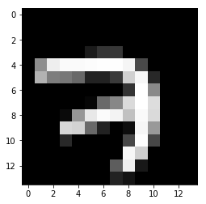

```python
q4dtr = downsample2(2, train_samp)
q4dtr_full = downsample2(2, train)
q4dts = downsample2(2, test)

x1 = np.reshape(q4dtr_full[0], [14,14])
matplot.imshow(x1, cmap='Greys_r')
matplot.show()
```

```python
q4n2 = knncv(q4dtr, trlab_samp, range(1,21))
```

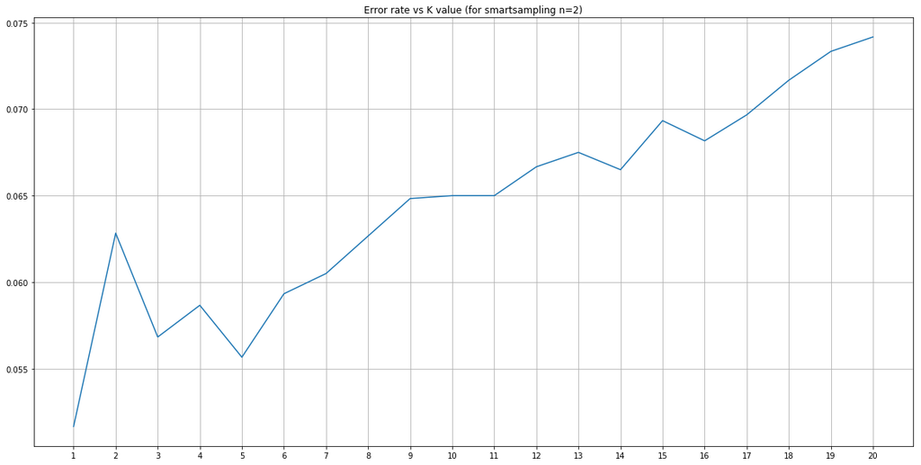

```python
matplot.subplots(figsize=(20, 10))
matplot.plot(np.mean(q4n2, axis = 0))
matplot.xticks(range(0,20), range(1,21))
matplot.grid(True)
matplot.title('Error rate vs K value (for smartsampling n=2)')
matplot.show()
```

#### best k: k = 1

```python
st = time()
q4d = knn(q4dtr_full, trlab, q4dts, tslab, 1)
end = time() - st
t4d = end/len(tslab) # Query time
```

```python
print(q4d[0]) # Error rate
```

```
0.0283
```

```python
q4d[1] # Confusion matrix
```

|  | 0 | 1 | 2 | 3 | 4 | 5 | 6 | 7 | 8 | 9 |
| --- | --- | --- | --- | --- | --- | --- | --- | --- | --- | --- |
| 0 | 971 | 1 | 2 | 0 | 0 | 2 | 2 | 1 | 1 | 0 |
| 1 | 0 | 1131 | 2 | 0 | 1 | 1 | 0 | 0 | 0 | 0 |
| 2 | 7 | 1 | 1003 | 2 | 2 | 0 | 2 | 10 | 5 | 0 |
| 3 | 1 | 0 | 3 | 966 | 1 | 19 | 0 | 5 | 9 | 6 |
| 4 | 0 | 1 | 0 | 0 | 949 | 0 | 3 | 3 | 2 | 24 |
| 5 | 1 | 1 | 0 | 8 | 1 | 865 | 5 | 1 | 7 | 3 |
| 6 | 5 | 2 | 0 | 1 | 2 | 4 | 944 | 0 | 0 | 0 |
| 7 | 0 | 12 | 6 | 2 | 6 | 0 | 0 | 990 | 1 | 11 |
| 8 | 2 | 1 | 4 | 13 | 4 | 10 | 4 | 4 | 929 | 3 |
| 9 | 1 | 5 | 1 | 6 | 9 | 5 | 1 | 10 | 2 | 969 |

```python
error_rate(q4d[1])
```

|  | Error rate |
| --- | --- |
| 0 | 0.009184 |
| 1 | 0.003524 |
| 2 | 0.028101 |
| 3 | 0.043564 |
| 4 | 0.033605 |
| 5 | 0.030269 |
| 6 | 0.014614 |
| 7 | 0.036965 |
| 8 | 0.046201 |
| 9 | 0.039643 |

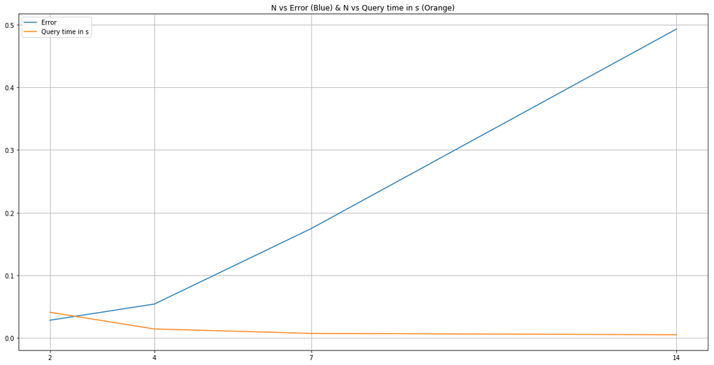

```python
n = [2,4,7,14]
err = [q4d[0],q4a[0],q4b[0],q4c[0]]
t = [t4d,t4a,t4b,t4c]

matplot.subplots(figsize=(20, 10))
matplot.plot(n, err, label="Error") # Blue
matplot.plot(n, t, label="Query time in s") # Orange
matplot.xticks(n,n)
matplot.grid(True)
matplot.legend()
matplot.title('N vs Error (Blue) & N vs Query time in s (Orange)')
matplot.show()
```

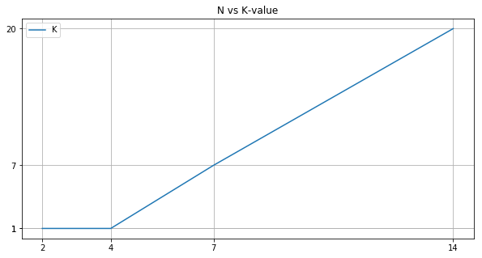

```python
n = [2,4,7,14]
k_val = [1,1,7,20]

matplot.subplots(figsize=(10, 5))
matplot.plot(n, k_val, label="K")
matplot.xticks(n,n)
matplot.yticks(k_val, k_val)
matplot.legend()
matplot.grid(True)
matplot.title('N vs K-value')
matplot.show()
```

- The query time decreases as the smartsampling factor N increases
- But, as N increases, K increases as well
- Also, as N increases, the Error rate increases
- Between N = 2 to N = 4 we have a sweet spot between K, Query time and Error Rate
- Note that, k=1 for N=2 and N=4

### N=28 smart sampling

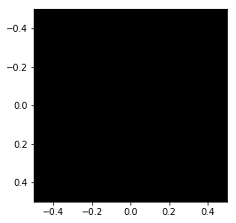

```python
q5tr = downsample2(28, train_samp)
q5tr_full = downsample2(28, train)
q5ts = downsample2(28, test)

x1 = np.reshape(q5tr_full[0], [1,1])
matplot.imshow(x1, cmap='Greys_r')
matplot.show()
```

```python
q5k = knncv(q5tr, trlab_samp, range(1,21))
```

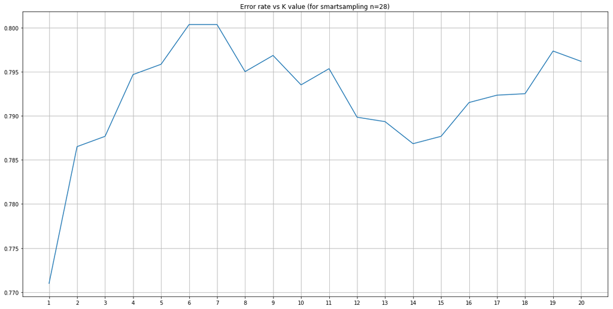

```python
matplot.subplots(figsize=(20, 10))
matplot.plot(np.mean(q5k, axis = 0))
matplot.xticks(range(0,20), range(1,21))
matplot.grid(True)
matplot.title('Error rate vs K value (for smartsampling n=28)')
matplot.show()
```

#### k = 1 has the better accuracy

```python
st = time()
q5 = knn(q5tr_full, trlab, q5ts, tslab, 1)
end = time() - st
print(end/len(tslab)) # Query time
```

```
0.004072939896583557
```

```python
print(q5[0]) # Error rate
```

```
0.8324
```

```python
q5[1] # Confusion matrix
```

|  | 0 | 1 | 2 | 3 | 4 | 5 | 6 | 7 | 8 | 9 |
| --- | --- | --- | --- | --- | --- | --- | --- | --- | --- | --- |
| 0 | 224 | 9 | 130 | 110 | 58 | 92 | 100 | 60 | 123 | 74 |
| 1 | 15 | 533 | 36 | 57 | 114 | 85 | 72 | 114 | 27 | 82 |
| 2 | 131 | 38 | 131 | 123 | 93 | 100 | 101 | 113 | 121 | 81 |
| 3 | 106 | 50 | 128 | 121 | 102 | 91 | 102 | 106 | 115 | 89 |
| 4 | 64 | 81 | 99 | 92 | 128 | 89 | 105 | 130 | 81 | 113 |
| 5 | 73 | 52 | 101 | 109 | 96 | 85 | 93 | 98 | 90 | 95 |
| 6 | 123 | 48 | 108 | 114 | 98 | 85 | 85 | 101 | 100 | 96 |
| 7 | 65 | 110 | 81 | 107 | 123 | 106 | 97 | 140 | 86 | 113 |
| 8 | 148 | 17 | 115 | 124 | 89 | 75 | 119 | 77 | 120 | 90 |
| 9 | 69 | 60 | 99 | 109 | 103 | 101 | 140 | 114 | 105 | 109 |

```python
error_rate(q5[1])
```

|  | Error rate |
| --- | --- |
| 0 | 0.771429 |
| 1 | 0.530396 |
| 2 | 0.873062 |
| 3 | 0.880198 |
| 4 | 0.869654 |
| 5 | 0.904709 |
| 6 | 0.911273 |
| 7 | 0.863813 |
| 8 | 0.876797 |
| 9 | 0.891972 |

- When we effectively reduce the size down to only 1 pixel, it takes a heavy toll on the accuracy, even though the query time decreases significantly

#### Out of all the different downsampling methods I would use SmartSampling with N=2 and K=1

Importing data

```python
import os
import gzip
import math
import operator
import sklearn.model_selection
import random

import matplotlib.pyplot as matplot
import matplotlib
%matplotlib inline
import pandas as pd
import numpy as np
import pickle as cPickle

from time import time
from itertools import chain
from collections import Counter
from PIL import Image
from scipy.stats import mode
from sklearn.metrics import confusion_matrix
from sklearn.metrics import accuracy_score
import warnings
warnings.filterwarnings('ignore')
```

```python
from tensorflow.examples.tutorials.mnist import input_data
mnist = input_data.read_data_sets('MNIST_data/')
```

```
Extracting MNIST_data/train-images-idx3-ubyte.gz
Extracting MNIST_data/train-labels-idx1-ubyte.gz
Extracting MNIST_data/t10k-images-idx3-ubyte.gz
Extracting MNIST_data/t10k-labels-idx1-ubyte.gz
```

```python
train = mnist.train.images
validation = mnist.validation.images
test = mnist.test.images

trlab = mnist.train.labels
vallab = mnist.validation.labels
tslab = mnist.test.labels

train = np.concatenate((train, validation), axis=0)
trlab = np.concatenate((trlab, vallab), axis=0)
```

KNN function

```python
def knn(train, train_label, test, test_label, k):
    pred = []
    for w in range(len(test)):
        test_1 = test[w]
        diff = (train - test_1)
        dist = np.einsum('ij, ij->i', diff, diff)  #distance measure
        nearest_lbs = train_label[np.argsort(dist)[:k]]
        major = mode(nearest_lbs)[0][0]
        pred.append(major)

    cm = pd.DataFrame(confusion_matrix(test_label, pred))
    err = 1-accuracy_score(test_label, pred)
    return [err,cm,pred]
```

Defining the error rate for the kNN to display in a tabulated format

```python
def error_rate(confusion_matrix):
    a = confusion_matrix
    b = a.sum(axis=1)
    df = []
    for i in range(0,10):
        temp = 1-a[i][i]/b[i]
        df.append(temp)

    df = pd.DataFrame(df)
    df.columns = ['Error rate']
    return df
```

KNN with Leave-one-out Cross validation

```python
def knncv(data, label, klist):
    df = pd.DataFrame(index=range(len(label)), columns=range(len(klist)))
    for p in range(len(label)):
        te = data[p]
        te_lb = label[p]
        tr = np.delete(data, p, 0)
        train_label = np.delete(label, p)

        diff = (tr - te)
        dis = np.einsum('ij, ij->i', diff, diff)
        for i, k in enumerate(klist):
            near = train_label[np.argsort(dis)[:k]]
            pick = mode(near)[0][0]
            if pick == te_lb:
                df.iloc[p][i] = 0
            else:
                df.iloc[p][i] = 1

    return df
```

Generating random sample of the data

```python
#generating a random sequence for sampling
seq = np.random.randint(0,60000,6000)
train_samp = train[seq]
trlab_samp = trlab[seq]

train_samp.shape
trlab_samp.shape
```

```
(6000,)
```

```python
seq = np.random.randint(0,10000,1000)
ts_samp = test[seq]
tslab_samp = tslab[seq]
```

Comparing sampled data distribution with the original

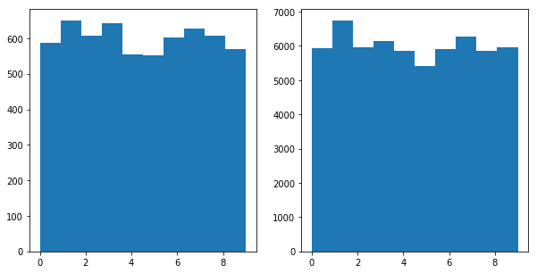

```python
fig, ax = matplot.subplots(1,2, figsize=(10,5))
ax[0].hist(trlab_samp)
ax[1].hist(trlab)
fig.show
matplot.show()
```

Comparing test samples as well

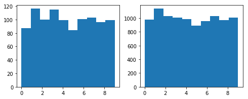

```python
fig, ax = matplot.subplots(1,2, figsize=(8,3))
ax[0].hist(tslab_samp)
ax[1].hist(tslab)
fig.show
matplot.show()
```

#### Convert greyscale to black and white

We see that all the images are in greyscale, we can put a threshold and convert the individual pixel values into 0 and 1, which will effectively render them black and white. Lets try with one image for example, and see the distribution

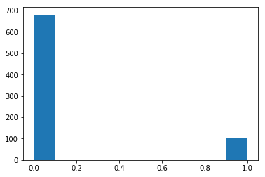

```python
temp = train[:,]>0.75
matplot.hist(temp[0])
matplot.show()
```

#### Black and white function

```python
def bnw(threshold, data):
    newdata = data[:,]>threshold
    return newdata
```

#### case (a): threshold = 0.75

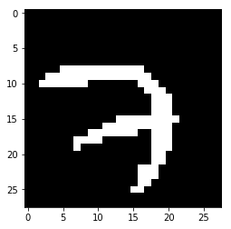

```python
q6tr_full = bnw(0.75, train)
q6ts = bnw(0.75, ts_samp)
q6tr = bnw(0.75, train_samp)

x1 = np.reshape(q6tr_full[0], [28,28])
matplot.imshow(x1, cmap='Greys_r')
matplot.show()
```

```python
q6k = knncv(q6tr, trlab_samp, range(1,21))
print(np.mean(q6k, axis = 0))
```

```
0     0.813833
1     0.855167
2     0.866167
3     0.868667
4     0.882667
5     0.882833
6     0.886667
7     0.882500
8     0.880000
9     0.883000
10    0.887333
11    0.895333
12    0.896500
13    0.893833
14    0.890667
15    0.893167
16    0.896500
17    0.899333
18    0.900000
19    0.900000
dtype: float64
```

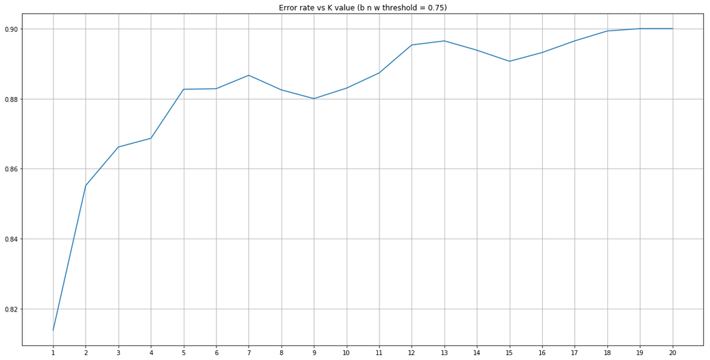

```python
matplot.subplots(figsize=(20, 10))
matplot.plot(np.mean(q6k, axis = 0))
matplot.xticks(range(0,20), range(1,21))
matplot.grid(True)
matplot.title('Error rate vs K value (b n w threshold = 0.75)')
matplot.show()
```

#### best k: k = 1

```python
st = time()
q6a = knn(q6tr, trlab_samp, q6ts, tslab_samp, 1)
end = time() - st
t6a = end/len(tslab_samp) # Query time
```

```python
print(q6a[0]) #Error rate
```

```
0.916
```

```python
q6a[1] #Confusion matrix
```

|  | 0 | 1 | 2 | 3 | 4 | 5 | 6 | 7 | 8 | 9 |
| --- | --- | --- | --- | --- | --- | --- | --- | --- | --- | --- |
| 0 | 0 | 0 | 0 | 0 | 0 | 87 | 0 | 0 | 0 | 0 |
| 1 | 0 | 0 | 0 | 0 | 0 | 116 | 0 | 0 | 0 | 0 |
| 2 | 0 | 0 | 0 | 0 | 0 | 100 | 0 | 0 | 0 | 0 |
| 3 | 0 | 0 | 0 | 0 | 0 | 115 | 0 | 0 | 0 | 0 |
| 4 | 0 | 0 | 0 | 0 | 0 | 99 | 0 | 0 | 0 | 0 |
| 5 | 0 | 0 | 0 | 0 | 0 | 84 | 0 | 0 | 0 | 0 |
| 6 | 0 | 0 | 0 | 0 | 0 | 101 | 0 | 0 | 0 | 0 |
| 7 | 0 | 0 | 0 | 0 | 0 | 103 | 0 | 0 | 0 | 0 |
| 8 | 0 | 0 | 0 | 0 | 0 | 96 | 0 | 0 | 0 | 0 |
| 9 | 0 | 0 | 0 | 0 | 0 | 99 | 0 | 0 | 0 | 0 |

```python
error_rate(q6a[1])
```

|  | Error rate |
| --- | --- |
| 0 | 1.0 |
| 1 | 1.0 |
| 2 | 1.0 |
| 3 | 1.0 |
| 4 | 1.0 |
| 5 | 0.0 |
| 6 | 1.0 |
| 7 | 1.0 |
| 8 | 1.0 |
| 9 | 1.0 |

#### case (b): threshold = 0.40

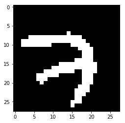

```python
q6tr_full = bnw(0.40, train)
q6ts = bnw(0.40, ts_samp)
q6tr = bnw(0.40, train_samp)

x1 = np.reshape(q6tr_full[0], [28,28])
matplot.imshow(x1, cmap='Greys_r')
matplot.show()
```

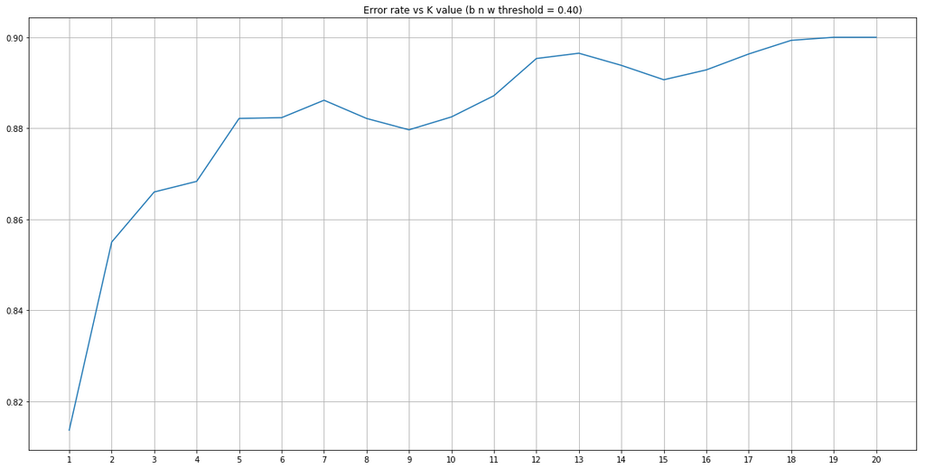

```python
q6b1 = knncv(q6tr, trlab_samp, range(1,21))
matplot.subplots(figsize=(20, 10))
matplot.plot(np.mean(q6b1, axis = 0))
matplot.xticks(range(0,20), range(1,21))
matplot.grid(True)
matplot.title('Error rate vs K value (b n w threshold = 0.40)')
matplot.show()
```

#### best k: k=1

```python
st = time()
q6b = knn(q6tr, trlab_samp, q6ts, tslab_samp, 1)
end = time() - st
t6b = end/len(tslab_samp) # Query time
```

```python
print(q6b[0]) #Error rate
```

```
0.916
```

```python
q6b[1] #Confusion matrix
```

|  | 0 | 1 | 2 | 3 | 4 | 5 | 6 | 7 | 8 | 9 |
| --- | --- | --- | --- | --- | --- | --- | --- | --- | --- | --- |
| 0 | 0 | 0 | 0 | 0 | 0 | 87 | 0 | 0 | 0 | 0 |
| 1 | 0 | 0 | 0 | 0 | 0 | 116 | 0 | 0 | 0 | 0 |
| 2 | 0 | 0 | 0 | 0 | 0 | 100 | 0 | 0 | 0 | 0 |
| 3 | 0 | 0 | 0 | 0 | 0 | 115 | 0 | 0 | 0 | 0 |
| 4 | 0 | 0 | 0 | 0 | 0 | 99 | 0 | 0 | 0 | 0 |
| 5 | 0 | 0 | 0 | 0 | 0 | 84 | 0 | 0 | 0 | 0 |
| 6 | 0 | 0 | 0 | 0 | 0 | 101 | 0 | 0 | 0 | 0 |
| 7 | 0 | 0 | 0 | 0 | 0 | 103 | 0 | 0 | 0 | 0 |
| 8 | 0 | 0 | 0 | 0 | 0 | 96 | 0 | 0 | 0 | 0 |
| 9 | 0 | 0 | 0 | 0 | 0 | 99 | 0 | 0 | 0 | 0 |

```python
error_rate(q6b[1])
```

|  | Error rate |
| --- | --- |
| 0 | 1.0 |
| 1 | 1.0 |
| 2 | 1.0 |
| 3 | 1.0 |
| 4 | 1.0 |
| 5 | 0.0 |
| 6 | 1.0 |
| 7 | 1.0 |
| 8 | 1.0 |
| 9 | 1.0 |

#### case (c): threshold = 0.50

[figure not shown]

```python
q6tr_full = bnw(0.50, train)
q6ts = bnw(0.50, ts_samp)
q6tr = bnw(0.50, train_samp)

x1 = np.reshape(q6tr_full[0], [28,28])
matplot.imshow(x1, cmap='Greys_r')
matplot.show()
```

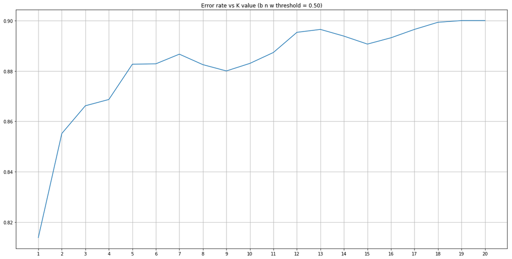

```python
q6c1 = knncv(q6tr, trlab_samp, range(1,21))
matplot.subplots(figsize=(20, 10))
matplot.plot(np.mean(q6c1, axis = 0))
matplot.xticks(range(0,20), range(1,21))
matplot.grid(True)
matplot.title('Error rate vs K value (b n w threshold = 0.50)')
matplot.show()
```

#### best k: k=1

```python
st = time()
q6c = knn(q6tr, trlab_samp, q6ts, tslab_samp, 1)
end = time() - st
t6c = end/len(tslab_samp) # Query time
```

```python
print(q6c[0]) #Error rate
```

```
0.916
```

```python
q6c[1] #Confusion matrix
```

|  | 0 | 1 | 2 | 3 | 4 | 5 | 6 | 7 | 8 | 9 |
| --- | --- | --- | --- | --- | --- | --- | --- | --- | --- | --- |
| 0 | 0 | 0 | 0 | 0 | 0 | 87 | 0 | 0 | 0 | 0 |
| 1 | 0 | 0 | 0 | 0 | 0 | 116 | 0 | 0 | 0 | 0 |
| 2 | 0 | 0 | 0 | 0 | 0 | 100 | 0 | 0 | 0 | 0 |
| 3 | 0 | 0 | 0 | 0 | 0 | 115 | 0 | 0 | 0 | 0 |
| 4 | 0 | 0 | 0 | 0 | 0 | 99 | 0 | 0 | 0 | 0 |
| 5 | 0 | 0 | 0 | 0 | 0 | 84 | 0 | 0 | 0 | 0 |
| 6 | 0 | 0 | 0 | 0 | 0 | 101 | 0 | 0 | 0 | 0 |
| 7 | 0 | 0 | 0 | 0 | 0 | 103 | 0 | 0 | 0 | 0 |
| 8 | 0 | 0 | 0 | 0 | 0 | 96 | 0 | 0 | 0 | 0 |
| 9 | 0 | 0 | 0 | 0 | 0 | 99 | 0 | 0 | 0 | 0 |

```python
error_rate(q6c[1])
```

|  | Error rate |
| --- | --- |
| 0 | 1.0 |
| 1 | 1.0 |
| 2 | 1.0 |
| 3 | 1.0 |
| 4 | 1.0 |
| 5 | 0.0 |
| 6 | 1.0 |
| 7 | 1.0 |
| 8 | 1.0 |
| 9 | 1.0 |

#### case (d): threshold = 0.60

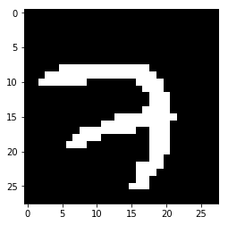

```python
q6tr_full = bnw(0.60, train)
q6ts = bnw(0.60, ts_samp)
q6tr = bnw(0.60, train_samp)

x1 = np.reshape(q6tr_full[0], [28,28])
matplot.imshow(x1, cmap='Greys_r')
matplot.show()
```

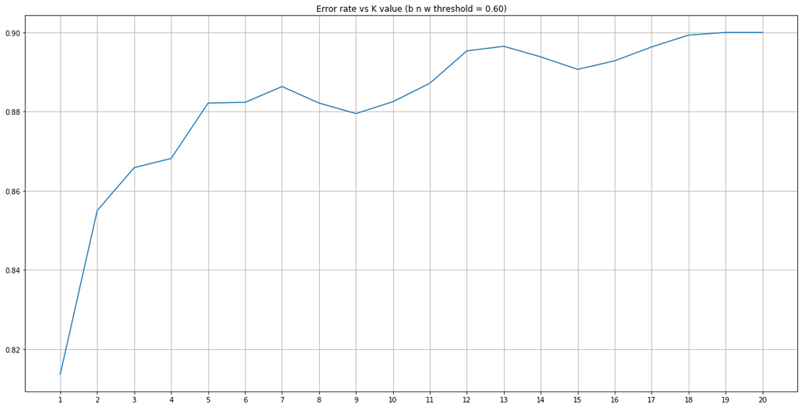

```python
q6d1 = knncv(q6tr, trlab_samp, range(1,21))
matplot.subplots(figsize=(20, 10))
matplot.plot(np.mean(q6d1, axis = 0))
matplot.xticks(range(0,20), range(1,21))
matplot.grid(True)
matplot.title('Error rate vs K value (b n w threshold = 0.60)')
matplot.show()
```

#### best k: k=1

```python
st = time()
q6d = knn(q6tr, trlab_samp, q6ts, tslab_samp, 1)
end = time() - st
t6d = end/len(tslab_samp) # Query time
```

```python
print(q6d[0]) #Error rate
```

```
0.916
```

```python
q6d[1] #Confusion matrix
```

|  | 0 | 1 | 2 | 3 | 4 | 5 | 6 | 7 | 8 | 9 |
| --- | --- | --- | --- | --- | --- | --- | --- | --- | --- | --- |
| 0 | 0 | 0 | 0 | 0 | 0 | 87 | 0 | 0 | 0 | 0 |
| 1 | 0 | 0 | 0 | 0 | 0 | 116 | 0 | 0 | 0 | 0 |
| 2 | 0 | 0 | 0 | 0 | 0 | 100 | 0 | 0 | 0 | 0 |
| 3 | 0 | 0 | 0 | 0 | 0 | 115 | 0 | 0 | 0 | 0 |
| 4 | 0 | 0 | 0 | 0 | 0 | 99 | 0 | 0 | 0 | 0 |
| 5 | 0 | 0 | 0 | 0 | 0 | 84 | 0 | 0 | 0 | 0 |
| 6 | 0 | 0 | 0 | 0 | 0 | 101 | 0 | 0 | 0 | 0 |
| 7 | 0 | 0 | 0 | 0 | 0 | 103 | 0 | 0 | 0 | 0 |
| 8 | 0 | 0 | 0 | 0 | 0 | 96 | 0 | 0 | 0 | 0 |
| 9 | 0 | 0 | 0 | 0 | 0 | 99 | 0 | 0 | 0 | 0 |

```python
error_rate(q6d[1])
```

|  | Error rate |
| --- | --- |
| 0 | 1.0 |
| 1 | 1.0 |
| 2 | 1.0 |
| 3 | 1.0 |
| 4 | 1.0 |
| 5 | 0.0 |
| 6 | 1.0 |
| 7 | 1.0 |
| 8 | 1.0 |
| 9 | 1.0 |

#### case (e): threshold = 0.90

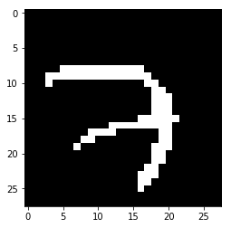

```python
q6tr_full = bnw(0.90, train)
q6ts = bnw(0.90, ts_samp)
q6tr = bnw(0.90, train_samp)

x1 = np.reshape(q6tr_full[0], [28,28])
matplot.imshow(x1, cmap='Greys_r')
matplot.show()
```

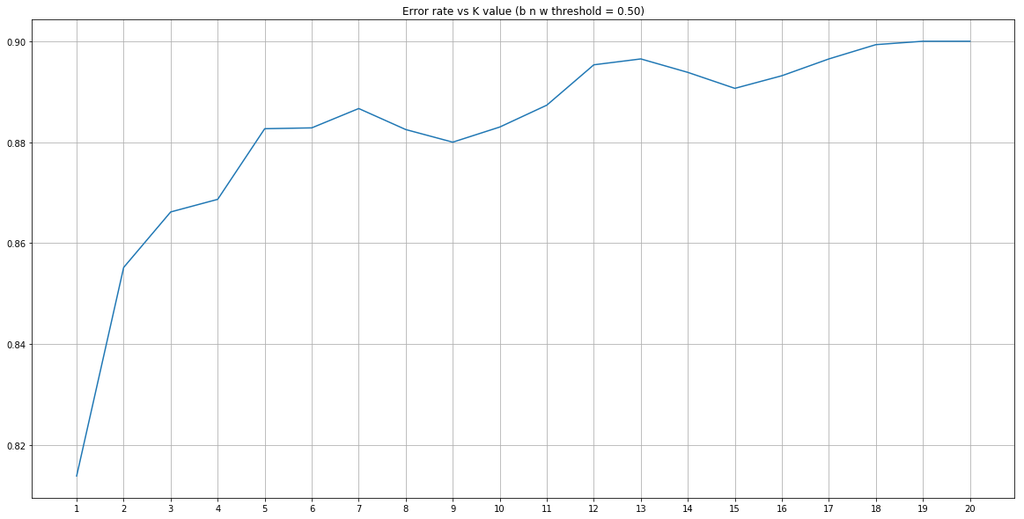

```python
q6e1 = knncv(q6tr, trlab_samp, range(1,21))
matplot.subplots(figsize=(20, 10))
matplot.plot(np.mean(q6e1, axis = 0))
matplot.xticks(range(0,20), range(1,21))
matplot.grid(True)
matplot.title('Error rate vs K value (b n w threshold = 0.50)')
matplot.show()
```

#### best k: k=1

```python
st = time()
q6e = knn(q6tr, trlab_samp, q6ts, tslab_samp, 1)
end = time() - st
t6e = end/len(tslab_samp) # Query time
```

```python
print(q6e[0]) #Error rate
```

```
0.914
```

```python
q6e[1] #Confusion matrix
```

|  | 0 | 1 | 2 | 3 | 4 | 5 | 6 | 7 | 8 | 9 |
| --- | --- | --- | --- | --- | --- | --- | --- | --- | --- | --- |
| 0 | 0 | 0 | 0 | 0 | 0 | 87 | 0 | 0 | 0 | 0 |
| 1 | 0 | 2 | 0 | 0 | 0 | 114 | 0 | 0 | 0 | 0 |
| 2 | 0 | 0 | 0 | 0 | 0 | 100 | 0 | 0 | 0 | 0 |
| 3 | 0 | 0 | 0 | 0 | 0 | 115 | 0 | 0 | 0 | 0 |
| 4 | 0 | 0 | 0 | 0 | 0 | 99 | 0 | 0 | 0 | 0 |
| 5 | 0 | 0 | 0 | 0 | 0 | 84 | 0 | 0 | 0 | 0 |
| 6 | 0 | 0 | 0 | 0 | 0 | 101 | 0 | 0 | 0 | 0 |
| 7 | 0 | 0 | 0 | 0 | 0 | 103 | 0 | 0 | 0 | 0 |
| 8 | 0 | 0 | 0 | 0 | 0 | 96 | 0 | 0 | 0 | 0 |
| 9 | 0 | 0 | 0 | 0 | 0 | 99 | 0 | 0 | 0 | 0 |

```python
error_rate(q6e[1])
```

|  | Error rate |
| --- | --- |
| 0 | 1.000000 |
| 1 | 0.982759 |
| 2 | 1.000000 |
| 3 | 1.000000 |
| 4 | 1.000000 |
| 5 | 0.000000 |
| 6 | 1.000000 |
| 7 | 1.000000 |
| 8 | 1.000000 |
| 9 | 1.000000 |

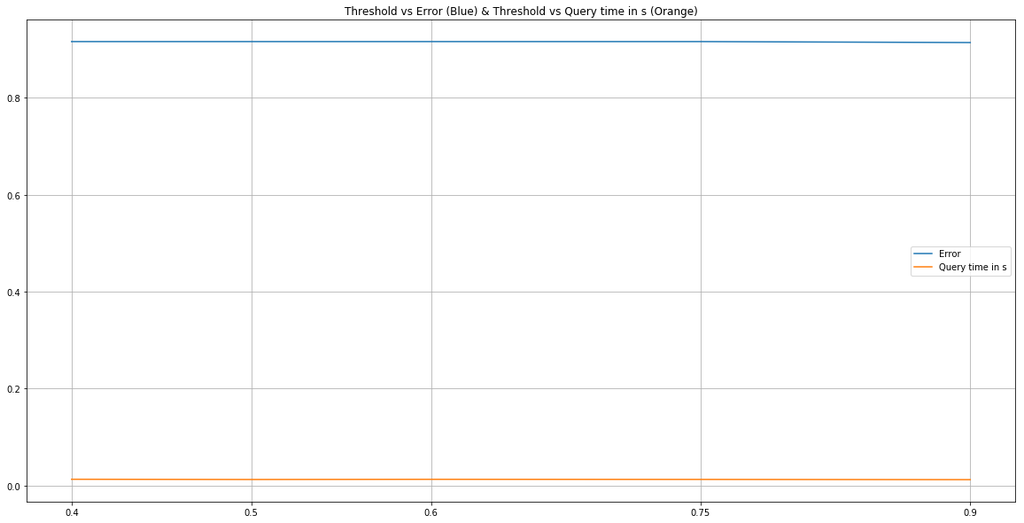

```python
thres = [0.40,0.50,0.60,0.75,0.90]
err = [q6b[0],q6c[0],q6d[0],q6a[0],q6e[0]]
t = [t6b,t6c,t6d,t6a,t6e]

matplot.subplots(figsize=(20, 10))
matplot.plot(thres, err, label="Error") # Blue
matplot.plot(thres, t, label="Query time in s") # Orange
matplot.xticks(thres,thres)
matplot.grid(True)
matplot.legend()
matplot.title('Threshold vs Error (Blue) & Threshold vs Query time in s (Orange)')
matplot.show()
```

- Very wierd results
- Everything is classified as 5
- No matter the Threshold, Error and Query time (with this method) remains constant
- Query time is no better than previous downsampling techniques
- Also to note that *K=1* for all the thresholds  
  **Striclty recomend not using this technique and develop further (better) downsampling techniques**